# Assignment 7_Sentiment analysis

Benjamin Inbar

2022-11-05

###### Sentiment analysis of US Presidential State of the Union speeches from 1950-2020. Originally, the idea was to scrape from a historical website, then to pull each of the cleaned Kaggle .txt files (https://www.kaggle.com/datasets/rtatman/state-of-the-union-corpus-1989-2017?resource=download) from my Github, but in the interest of time, I chose to use the very handy R ‘sotu’ package (https://github.com/statsmaths/sotu/).

###### Note that a portion of this code was borrowed from chapter 2 of “Text Mining in R: A Tidy Approach” by Julia Silge and David Robinson, which can be found here: https://www.tidytextmining.com/sentiment.html.

```r
library(tidyverse)
library(tidytext)
library(sotu)
library(stringr)
library(ggplot2)
library(wordcloud)

head(sotu_meta)
```

```
##   X         president year years_active       party sotu_type
## 1 1 George Washington 1790    1789-1793 Nonpartisan    speech
## 2 2 George Washington 1790    1789-1793 Nonpartisan    speech
## 3 3 George Washington 1791    1789-1793 Nonpartisan    speech
## 4 4 George Washington 1792    1789-1793 Nonpartisan    speech
## 5 5 George Washington 1793    1793-1797 Nonpartisan    speech
## 6 6 George Washington 1794    1793-1797 Nonpartisan    speech
```

```r
sotu_text[[1]]
```

```
## [1] "Fellow-Citizens of the Senate and House of Representatives: \n\nI embrace with great satisfaction the opportunity which now presents itself of congratulating you on the present favorable prospects of our public affairs. The recent accession of the important state of North Carolina to the Con…
```

Take a subset of speeches from 1950-2020. We want the sentiment analyses to better match, and text from older speeches may not match as well.

```r
metaset <- sotu_meta |> filter(sotu_meta$year>=1950)
textset <- tail(sotu_text, n=79)

metaset <- mutate(metaset, text=textset)
metaset[, c('X', 'sotu_type')] <- NULL
rownames(metaset) = seq(length=nrow(metaset))
```

NRC lexicon citation: This dataset was published in Saif M. Mohammad and Peter Turney. (2013), “Crowdsourcing a Word-Emotion Association Lexicon.” Computational Intelligence, 29(3): 436-465.

```r
nrc <- get_sentiments('nrc')
afinn <- get_sentiments('afinn')
bing <- get_sentiments('bing')
```

Extract words, and append words with president, year, and party to a new dataframe in long format.

```r
words_all <- data.frame()
for (corpus in 1:nrow(metaset)) {
  words <- str_extract_all(metaset[corpus, 'text'], "[[:alpha:]]+")
  for (word in words) {
    df <- cbind(word, president=metaset[corpus, 'president'], year=metaset[corpus, 'year'], party=metaset[corpus, 'party'])
  }
  words_all <- rbind(words_all, df)
}
```

Perform the same analysis as shown in Ch. 2 of Text Mining with R to get an overall sentiment score, but instead of per book, do so per President. Normalize across 100-word chunks of speech, for all speeches, per President.

```r
bing_analysis1 <- words_all |> inner_join(bing) |> count(party, president, index=row_number() %/% 100, sentiment) |>
  pivot_wider(names_from = sentiment, values_from = n) |> mutate(sentiment = positive - negative)
```

Plot, colorizing by party affiliation.

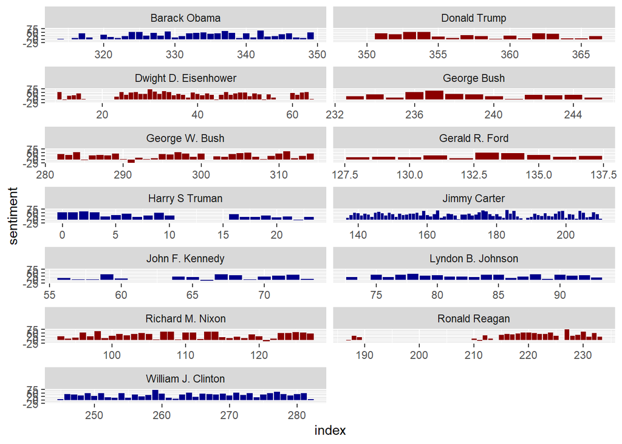

```r
ggplot(bing_analysis1, aes(index, sentiment, fill=party)) +
  geom_col(show.legend = FALSE) +
  facet_wrap(~president, ncol = 2, scales = "free_x") +
  scale_fill_manual(values=c("darkblue", "darkred"))
```

That was nice to see, but it might be better to just aggregate sentiment for each President. Normalize to 800 word chunks.

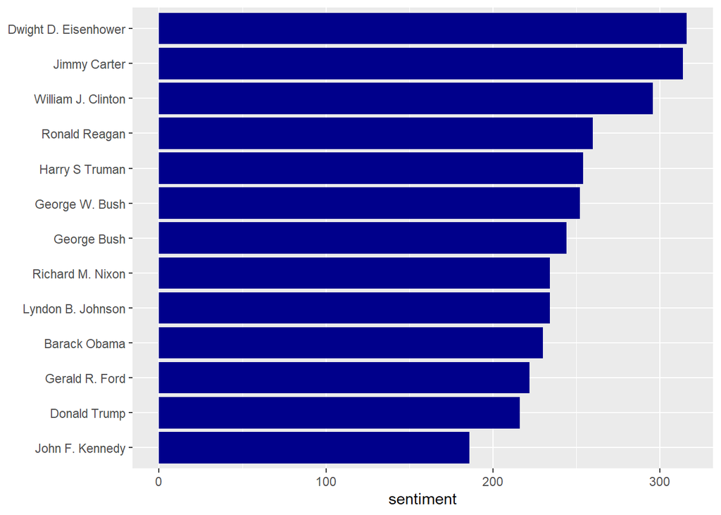

```r
bing_analysis2 <- words_all |> inner_join(bing) |> group_by(president) |> slice_sample(n=800) |> count(sentiment) |>
  pivot_wider(names_from = sentiment, values_from = n) |> mutate(sentiment = positive - negative)

ggplot(bing_analysis2, aes(reorder(president, sentiment), sentiment)) +
  geom_col(show.legend = FALSE, fill='darkblue') +
  coord_flip() +
  theme(axis.title.y=element_blank())
```

To compare the other sentiment analysis lexicons, let’s filter for just one President, Jimmy Carter, who seems to have the most verbose speeches. The following code is only minimally adapted from Ch. 2 of Text Mining with R.

```r
jimmycarter <- words_all |> filter(president == "Jimmy Carter")
```

Use ‘afinn’ lexicon to get the -5 to +5 score for each word, summarize to get sum for all word scores for each chunk.

```r
afinn <- jimmycarter |> inner_join(afinn) |> group_by(index = row_number() %/% 100) |>
  summarise(sentiment = sum(value)) |> mutate(method = "AFINN")
print(afinn, n=10)
```

```
## # A tibble: 71 × 3
##    index sentiment method
##    <dbl>     <dbl> <chr>
##  1     0        16 AFINN
##  2     1        62 AFINN
##  3     2        96 AFINN
##  4     3        73 AFINN
##  5     4        47 AFINN
##  6     5        83 AFINN
##  7     6        86 AFINN
##  8     7        57 AFINN
##  9     8       111 AFINN
## 10     9        92 AFINN
## # … with 61 more rows
```

Use BOTH ‘bing’ and ‘nrc’ lexicons to get the positive/negative sentiments, pivot wide, and add net sentiment calculation.

```r
bing_and_nrc <- bind_rows(jimmycarter |> inner_join(bing) |> mutate(method = "Bing"), jimmycarter |> inner_join(nrc) |>
  filter(sentiment %in% c("positive", "negative")) |> mutate(method = "NRC")) |> count(method, index = row_number() %/% 100, sentiment) |>
  pivot_wider(names_from = sentiment, values_from = n, values_fill = 0) |>
  mutate(sentiment = positive - negative)
head(bing_and_nrc)
```

```
## # A tibble: 6 × 5
##   method index negative positive sentiment
##   <chr>  <dbl>    <int>    <int>     <int>
## 1 Bing       0       44       55        11
## 2 Bing       1       26       74        48
## 3 Bing       2       25       75        50
## 4 Bing       3       32       68        36
## 5 Bing       4       32       68        36
## 6 Bing       5       31       69        38
```

```r
tail(bing_and_nrc)
```

```
## # A tibble: 6 × 5
##   method index negative positive sentiment
##   <chr>  <dbl>    <int>    <int>     <int>
## 1 NRC      185       33       67        34
## 2 NRC      186       21       79        58
## 3 NRC      187       21       79        58
## 4 NRC      188       17       83        66
## 5 NRC      189       29       71        42
## 6 NRC      190        8       30        22
```

Bind both ‘afinn’ and ‘bing’/‘nrc’ tibbles and graph sentiment. Interesting that for SOTU speeches, unlike for Pride and Prejudice, AFINN shows higher values than the other lexicons instead of NRC.

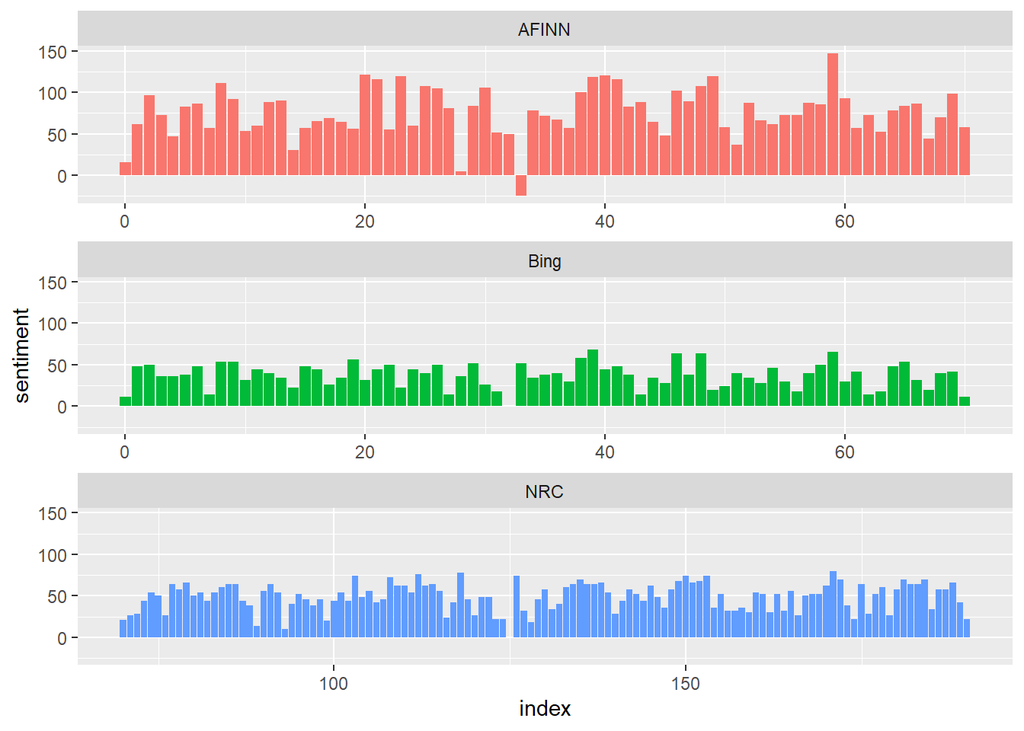

```r
bind_rows(afinn, bing_and_nrc) |>
  ggplot(aes(index, sentiment, fill = method)) +
  geom_col(show.legend = FALSE) +
  facet_wrap(~method, ncol = 1, scales = "free_x")
```

Quick look at the word cloud for all words, not including stop words.

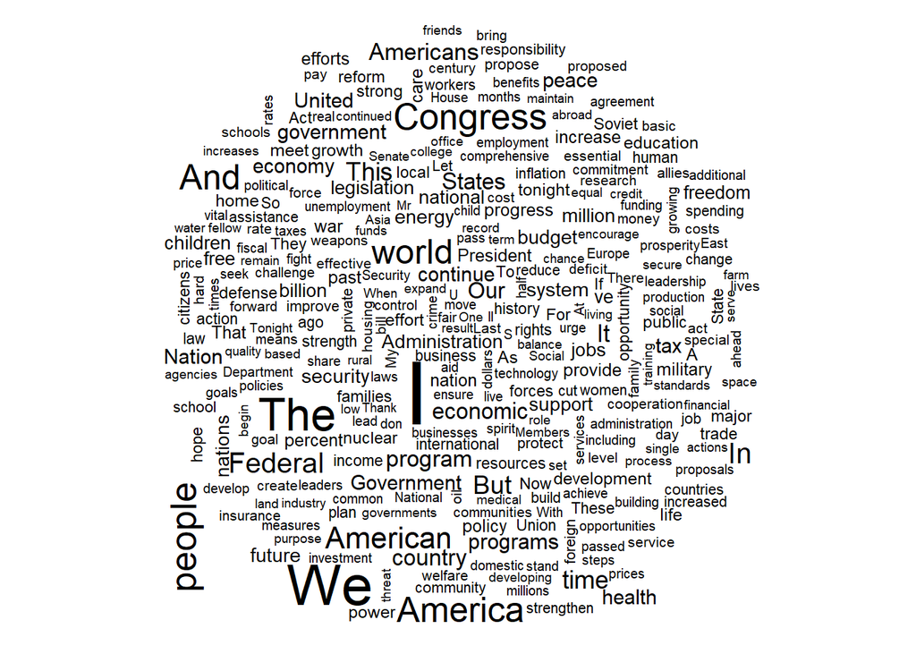

```r
words_all_nostop <- words_all |> anti_join(stop_words)
words_all_nostop |> count(word) |> with(wordcloud(word, n, max.words = 300))
```

##### Extend this analysis using the ‘loughran’ lexicon, which I believe is part of the umbrella source for the lexicons established above.

```r
loughran <- get_sentiments('loughran')
```

Perform the same analysis as above for all Presidents, using loughran.

```r
loughran_analysis1 <- words_all |> inner_join(loughran) |> count(party, president, index=row_number() %/% 100, sentiment) |>
  pivot_wider(names_from = sentiment, values_from = n) |> mutate(sentiment = positive - negative)
```

Plot, again colorizing by party affiliation. Huge difference! We see a much more negative trends overall.

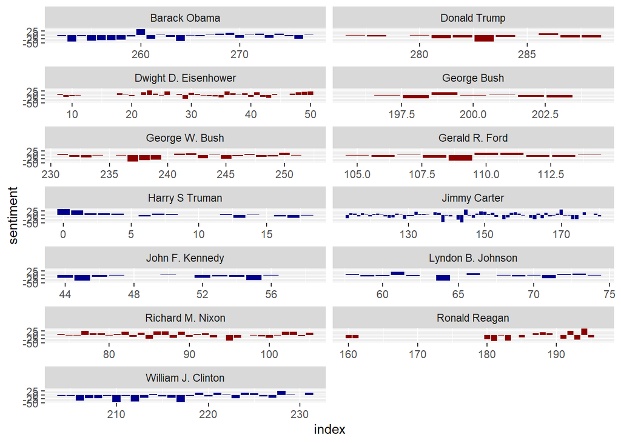

```r
ggplot(loughran_analysis1, aes(index, sentiment, fill=party)) +
  geom_col(show.legend = FALSE) +
  facet_wrap(~president, ncol = 2, scales = "free_x") +
  scale_fill_manual(values=c("darkblue", "darkred"))
```

```r
loughran_analysis2 <- loughran_analysis1 |> select(c('index', 'negative', 'positive', 'sentiment')) |> mutate(method='loughran')
```

Combine and plot. It is very clear loughran has much more negative sentiment scoring, compared with any of the other lexicons.

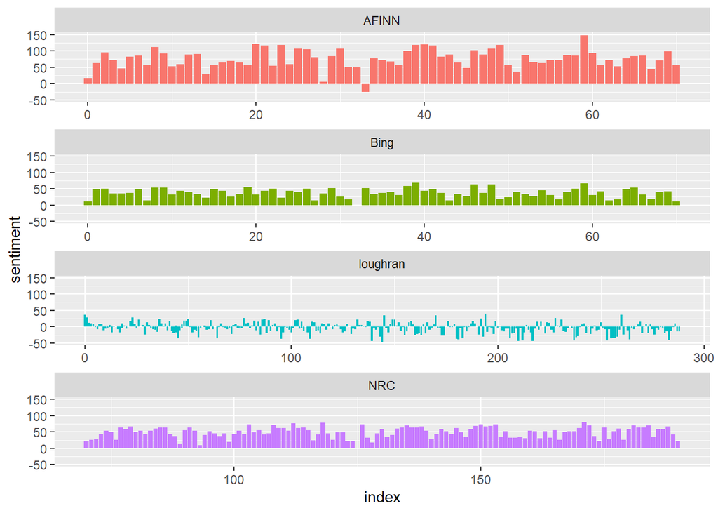

```r
bing_nrc_loughran <- bind_rows(bing_and_nrc, loughran_analysis2, afinn)
ggplot(bing_nrc_loughran, aes(index, sentiment, fill = method)) +
  geom_col(show.legend = FALSE) +
  facet_wrap(~method, ncol = 1, scales = "free_x")
```